# Modelo Probit Microeconometria

Ismael Giancarlo Aguedo Aguilar

# Datos

Incluimos los datos de 32 observaciones sobre el efecto de un sistema personalizado de instrucción (PSI) en las calificaciones del curso:

- Variable Endogena GRADE:(GRADE = 1 si la calificación es obtenida es A, GRADE = 0 si la calificación es obtenida es diferente de A)
- Variables Exógenas: GPA: Promedio de notas de entrada; TUCE: Puntuación en un examen de principio del curso; PSI:(PSI = 1 si se utiliza el nuevo método, PSI = 0 si no se utiliza el nuevo método)

Efecto de un sistema personalizado de instrucción

| GPA | TUCE | PSI | GRADE |
| --- | --- | --- | --- |
| 2.66 | 20 | 0 | 0 |
| 2.89 | 22 | 0 | 0 |
| 3.28 | 24 | 0 | 0 |
| 2.92 | 12 | 0 | 0 |
| 4.00 | 21 | 0 | 1 |
| 2.86 | 17 | 0 | 0 |
| 2.76 | 17 | 0 | 0 |
| 2.87 | 21 | 0 | 0 |
| 3.03 | 25 | 0 | 0 |
| 3.92 | 29 | 0 | 1 |
| 2.63 | 20 | 0 | 0 |
| 3.32 | 23 | 0 | 0 |
| 3.57 | 23 | 0 | 0 |
| 3.26 | 25 | 0 | 1 |
| 3.53 | 26 | 0 | 0 |
| 2.74 | 19 | 0 | 0 |
| 2.75 | 25 | 0 | 0 |
| 2.83 | 19 | 0 | 0 |
| 3.12 | 23 | 1 | 0 |
| 3.16 | 25 | 1 | 1 |
| 2.06 | 22 | 1 | 0 |
| 3.62 | 28 | 1 | 1 |
| 2.89 | 14 | 1 | 0 |
| 3.51 | 26 | 1 | 0 |
| 3.54 | 24 | 1 | 1 |
| 2.83 | 27 | 1 | 1 |
| 3.39 | 17 | 1 | 1 |
| 2.67 | 24 | 1 | 0 |
| 3.65 | 21 | 1 | 1 |
| 4.00 | 23 | 1 | 1 |
| 3.10 | 21 | 1 | 0 |
| 2.39 | 19 | 1 | 1 |

# Estimación del Modelo

## Estimación Probit:

Bien por motivos didácticos mostramos solamente los coeficientes, con el cual podemos plasmar la ecuación estimada y la probabilidad de que GRADE sea igual a 1:

```
Call:
glm(formula = GRADE ~ GPA + TUCE + PSI, family = binomial(link = "probit"),
    data = instruc)

Coefficients:
            Estimate Std. Error z value Pr(>|z|)
(Intercept) -7.45231    2.57152  -2.898  0.00376 **
GPA          1.62581    0.68973   2.357  0.01841 *
TUCE         0.05173    0.08119   0.637  0.52406
PSI1         1.42633    0.58695   2.430  0.01510 *
---
Signif. codes:  0 '***' 0.001 '**' 0.01 '*' 0.05 '.' 0.1 ' ' 1

(Dispersion parameter for binomial family taken to be 1)

    Null deviance: 41.183  on 31  degrees of freedom
Residual deviance: 25.638  on 28  degrees of freedom
AIC: 33.638

Number of Fisher Scoring iterations: 6
```

Bien los errores se diferencian por décimas con estimaciones de otros programas, esto se debe al numero de iteraciones que usa cada algoritmo, pero en síntesis no afecta el análisis.

## Coeficientes Probit:

```
Coefficients:
             Estimate Std. Error   z value Pr(>|z|)
(Intercept) -7.452313   2.571523 -2.898016 0.003755
GPA          1.625812   0.689731  2.357168 0.018415
TUCE         0.051728   0.081194  0.637097 0.524062
PSI1         1.426331   0.586953  2.430058 0.015096
```

# Ecuación Probit

$$\scriptsize{I_{GRADE}=\beta_{1}+\beta_{2}\cdot
GPA+\beta_{3}\cdot TUCE+\beta_{4}\cdot PSI}$$
donde $I_{GRADE}$ representa el indicador binomial de GRADE.

## Ecuación del pronostico:

$$\scriptsize{P(GRADE=1)=1-\Phi-(\beta_{1}+\beta_{2}\cdot
GPA+\beta_{3}\cdot TUCE+\beta_{4}\cdot PSI)}$$
remplazando con los coeficientes obtenidos tenemos que:

$$\scriptsize{P(GRADE=1) = 1 -
\Phi\left(-(-7.452313 + 1.625812 \cdot GPA + 0.051728 \cdot TUCE +
1.426331 \cdot PSI)\right)}$$
Evidentemente para lograr obtener la probabilidad acumulada de que (GRADE=1), necesitamos los valores de las variables que en este caso no los tenemos. Si tuviéramos los valores y sabiendo que una muestra de datos lo suficientemente grande tiende a una distribución normal en Probit, podríamos determinar mediante la tabla de distribución normal acumulada dicha probabilidad.

A continuación muestro un gráfico de ejemplo de lo que seria la probabilidad acumulada, el área sombreada:

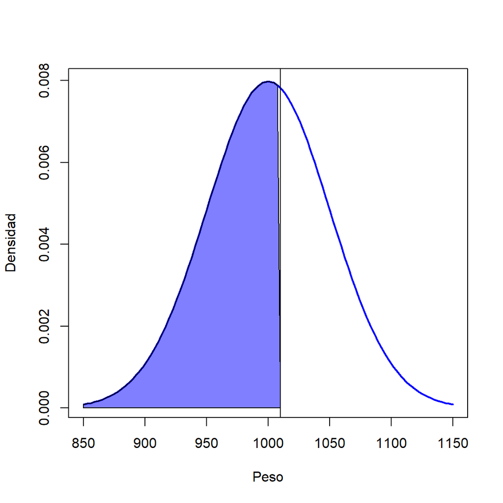

Distribución Normal Acumulativa

# R^2 McFadden

El R^2 McFadden es un pseudo R^2, se usa este estadístico por que el R^2 que se usa en modelos con MCO no resulta confiable en estos modelos.

```
[1] "R2 de McFadden: c(`McFadden's R2` = 0.377478033279115)"
[2] "R2 de McFadden: c(`adjusted McFadden's R2` = 0.328914847246022)"
```

En nuestro caso, el valor de McFadden’s R^2 es 0.377, lo que indica que el modelo Probit explica el 37.7% de la variación de la variable respuesta, en comparación con el modelo nulo. Este valor se considera moderado, pero no hay un criterio único para interpretarlo. Algunos autores sugieren que valores entre 0.2 y 0.4 son EXCELENTES, mientras que otros proponen medidas alternativas.

# Cuenta R^2

Entre los contrastes que miden la bondad de ajuste de estos modelos se encuentra el porcentaje de aciertos estimados ó “Cuenta R^2” que se define como:

$$\text{Cuenta }R^{2}=\frac{\text{numero
de predicciones correctas}}{\text{numero total de
observaciones}}$$
El valor del R2 de conteo en probit varía entre 0 y 1, siendo más cercano a 1 cuanto mejor sea el ajuste del modelo. Para hallar estas predicciones seguimos los siguientes pasos:

## Predicciones y residuos:

ACTUAL, FITTED Y RESIDUAL

| GRADE | Predicciones | Residuos |
| --- | --- | --- |
| 0 | 0.0181708 | -0.0181708 |
| 0 | 0.0530807 | -0.0530807 |
| 0 | 0.1899268 | -0.1899268 |
| 0 | 0.0185710 | -0.0185710 |
| 1 | 0.5545768 | 0.4454232 |
| 0 | 0.0272333 | -0.0272333 |
| 0 | 0.0185035 | -0.0185035 |
| 0 | 0.0445716 | -0.0445716 |
| 0 | 0.1088083 | -0.1088083 |
| 1 | 0.6631210 | 0.3368790 |
| 0 | 0.0161025 | -0.0161025 |
| 0 | 0.1935572 | -0.1935572 |
| 0 | 0.3233293 | -0.3233293 |
| 1 | 0.1951830 | 0.8048170 |
| 0 | 0.3563411 | -0.3563411 |
| 0 | 0.0219656 | -0.0219656 |
| 0 | 0.0456943 | -0.0456943 |
| 0 | 0.0308515 | -0.0308515 |
| 0 | 0.5934024 | -0.5934024 |
| 1 | 0.6571861 | 0.3428139 |
| 0 | 0.0619286 | -0.0619286 |
| 1 | 0.9045387 | 0.0954613 |
| 0 | 0.2731922 | -0.2731922 |
| 0 | 0.8474501 | -0.8474501 |
| 1 | 0.8341949 | 0.1658051 |
| 1 | 0.4887252 | 0.5112748 |
| 1 | 0.6424087 | 0.3575913 |
| 0 | 0.3286728 | -0.3286728 |
| 1 | 0.8400175 | 0.1599825 |
| 1 | 0.9522449 | 0.0477551 |
| 0 | 0.5399600 | -0.5399600 |
| 1 | 0.1235441 | 0.8764559 |

```
R2 de conteo: 0.8125
```

## Curva ROC:

Aprovecahando estos resultados podemos graficar la Curva ROC y determinar el area bajo la Curva. La Curva ROC es una herramienta comúnmente utilizada para evaluar el rendimiento de un modelo de clasificación binaria a diferentes umbrales de probabilidad de clasificación. Muestra la tasa de verdaderos positivos (sensibilidad) frente a la tasa de falsos positivos (1 - especificidad) a medida que se varía el umbral de clasificación.

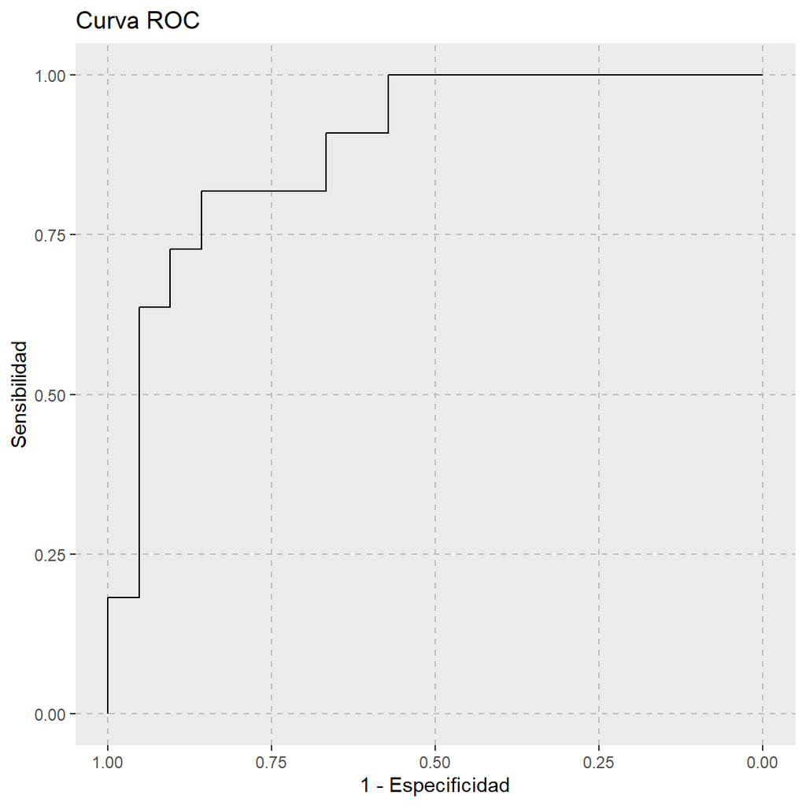

```
Área bajo la curva ROC (AUC): 0.8874459
```

Un valor de 0.8874459 para el área bajo la curva (AUC) sugiere que el modelo tiene una buena capacidad predictiva.

# Estadístico de la razón de verosimilitud (RV)

```
Likelihood ratio test

Model 1: GRADE ~ GPA + TUCE + PSI
Model 2: GRADE ~ 1
  #Df  LogLik Df  Chisq Pr(>Chisq)
1   4 -12.819
2   1 -20.592 -3 15.546   0.001405 **
---
Signif. codes:  0 '***' 0.001 '**' 0.01 '*' 0.05 '.' 0.1 ' ' 1
```

El Likelihood Ratio Test compara dos modelos: uno que incluye las covariables GPA, TUCE y PSI (Modelo 1) y otro que solo incluye la constante (Modelo 2). La prueba determina si agregar covariables mejora significativamente la capacidad del modelo.

# Grafico del modelo Probit

Ordeno las predicciones y luego creo el gráfico de la Curva de Probit de esa manera, se construye lo que se conoce como la “Curva S de Probit” o simplemente la función de distribución acumulativa (CDF) de las predicciones del modelo probit.

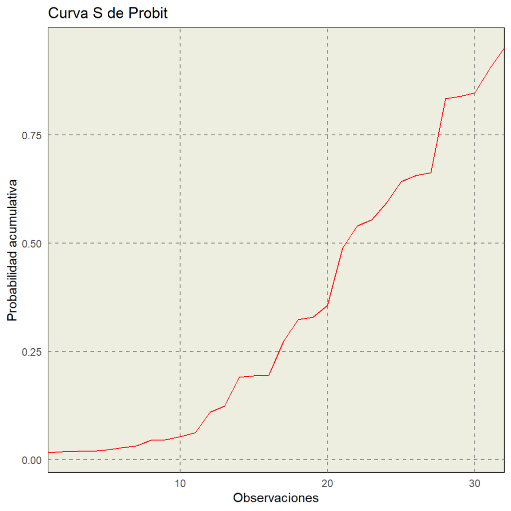

La Curva S de Probit proporciona una representación visual de cómo cambia la probabilidad acumulativa a medida que te desplazas a través de las predicciones ordenadas del modelo probit. Es una herramienta útil para comprender la distribución acumulativa de las probabilidades pronosticadas.

# Efectos Marginales en Probit

```
Call:
probitmfx(formula = fit, data = instruc)

Marginal Effects:
        dF/dx Std. Err.      z    P>|z|
GPA  0.533348  0.226667 2.3530 0.018622 *
TUCE 0.016970  0.026322 0.6447 0.519125
PSI1 0.464426  0.171258 2.7119 0.006691 **
---
Signif. codes:  0 '***' 0.001 '**' 0.01 '*' 0.05 '.' 0.1 ' ' 1

dF/dx is for discrete change for the following variables:

[1] "PSI1"
```

- GPA: Si tu promedio de notas de entrada (GPA) aumenta en una unidad, es más probable que obtengas una calificación A (GRADE = 1), y este aumento es estadísticamente significativo.
- TUCE: Cambiar tu puntuación en un examen de inicio de curso (TUCE) en una unidad no tiene un efecto claro y significativo en la probabilidad de obtener una calificación A (GRADE = 1).
- PSI1: Si utilizas el nuevo método de instrucción (PSI = 1), es más probable que obtengas una calificación A (GRADE = 1) en comparación con no utilizar el nuevo método (PSI = 0), y este cambio es estadísticamente significativo.

En resumen, el desempeño académico previo (GPA) y la adopción del nuevo método de instrucción (PSI1) están relacionados con tus probabilidades de obtener una calificación A (GRADE = 1) en el modelo Probit.